# Impact of Severe Weather Events on Public Health and the Economy

*Terence Lim, 17 January 2015*

## Synopsis

Storms and other severe weather events can cause both public health and economic problems for communities and municipalities. Many severe events can result in fatalities, injuries, and property damage, and preventing such outcomes to the extent possible is a key concern.

This project involves exploring the U.S. National Oceanic and Atmospheric Administration’s (NOAA) storm database to solve two major questions.

```
1. Across the United States, which types of events are most harmful with respect to population health?
2. Across the United States, which types of events have the greatest economic consequences?
```

Thorough analysis of this data has led to the conclusion that:

```
1. Tornadoes are the most detrimental to human health.
2. Flooding causes the greatest economic damage.
```

## Data Processing

### Load the relevant libraries

```r
library(dplyr)
library(tidyr)
library(ggplot2)
```

### Download and load data from U.S. National Oceanic and Atmospheric Administration’s (NOAA) storm database

```r
url = "https://d396qusza40orc.cloudfront.net/repdata%2Fdata%2FStormData.csv.bz2"
filename = "repdata-data-StormData.csv"
data.filename = "repdata-data-StormData.csv.bz2"

if(sum(data.filename %in% list.files())==0)
    download.file(url,filename)

storm_data <- tbl_df(read.csv(bzfile("./repdata-data-StormData.csv.bz2")))
```

### Remove unnecessary variables

After reading the documentation, only the few variables below are necessary for our analysis:

- EVTYPE : Event Type
- FATALITIES: Number of fatalities
- INJURIES : Number of injuries
- PROPDMG : Property Damage
- PROPDMGEXP: Property Damage Exponent which modifies PROPDMG based on whether it is k,b,m etc.
- CROPDMG : Crop Damange
- CROPDMGEXP: Crop Damage Exponent which modifies PROPDMG based on whether it is k,b,m etc.

```r
names(storm_data)
```

```
##  [1] "STATE__"    "BGN_DATE"   "BGN_TIME"   "TIME_ZONE"  "COUNTY"
##  [6] "COUNTYNAME" "STATE"      "EVTYPE"     "BGN_RANGE"  "BGN_AZI"
## [11] "BGN_LOCATI" "END_DATE"   "END_TIME"   "COUNTY_END" "COUNTYENDN"
## [16] "END_RANGE"  "END_AZI"    "END_LOCATI" "LENGTH"     "WIDTH"
## [21] "F"          "MAG"        "FATALITIES" "INJURIES"   "PROPDMG"
## [26] "PROPDMGEXP" "CROPDMG"    "CROPDMGEXP" "WFO"        "STATEOFFIC"
## [31] "ZONENAMES"  "LATITUDE"   "LONGITUDE"  "LATITUDE_E" "LONGITUDE_"
## [36] "REMARKS"    "REFNUM"
```

```r
storm_data <- storm_data[c("EVTYPE","FATALITIES","INJURIES","PROPDMG",
                           "PROPDMGEXP","CROPDMG","CROPDMGEXP")]

storm_data$EVTYPE <- tolower(as.character(storm_data$EVTYPE))
storm_data$PROPDMGEXP <- tolower(as.character(storm_data$PROPDMGEXP))
storm_data$CROPDMGEXP <- tolower(as.character(storm_data$CROPDMGEXP))
```

### Convert Exponents to numeric value

```r
unique(storm_data$PROPDMGEXP)
```

```
##  [1] "k" "m" ""  "b" "+" "0" "5" "6" "?" "4" "2" "3" "h" "7" "-" "1" "8"
```

```r
storm_data$PROPDMGEXP[storm_data$PROPDMGEXP=="k"]="1000"
storm_data$PROPDMGEXP[storm_data$PROPDMGEXP=="m"]="1000000"
storm_data$PROPDMGEXP[storm_data$PROPDMGEXP=="b"]="1000000000"
storm_data$PROPDMGEXP[storm_data$PROPDMGEXP==""]="0"
storm_data$PROPDMGEXP[storm_data$PROPDMGEXP=="-"]="0"
storm_data$PROPDMGEXP[storm_data$PROPDMGEXP=="?"]="0"
storm_data$PROPDMGEXP[storm_data$PROPDMGEXP=="+"]="1"
storm_data$PROPDMGEXP[c(0,1,2,3,4,5,6,7,8,9) %in% storm_data$PROPDMGEXP]="10"

unique(storm_data$CROPDMGEXP)
```

```
## [1] ""  "m" "k" "b" "?" "0" "2"
```

```r
storm_data$CROPDMGEXP[storm_data$CROPDMGEXP=="k"]="1000"
storm_data$CROPDMGEXP[storm_data$CROPDMGEXP=="m"]="1000000"
storm_data$CROPDMGEXP[storm_data$CROPDMGEXP=="b"]="1000000000"
storm_data$CROPDMGEXP[storm_data$CROPDMGEXP==""]="0"
storm_data$CROPDMGEXP[storm_data$CROPDMGEXP=="-"]="0"
storm_data$CROPDMGEXP[storm_data$CROPDMGEXP=="?"]="0"
storm_data$CROPDMGEXP[storm_data$CROPDMGEXP=="+"]="1"
storm_data$CROPDMGEXP[c(0,1,2,3,4,5,6,7,8,9) %in% storm_data$CROPDMGEXP]="10"
```

### Calculate actual damage values

Calculate actual damage values and store them in two new variables:

- PROP_DMG = PROPDMG * PROPDMGEXP
- CROP_DMG = CROPDMG * CROPDMGEXP

```r
storm_data$PROPDMGEXP <- as.numeric(storm_data$PROPDMGEXP)
storm_data$CROPDMGEXP <- as.numeric(storm_data$CROPDMGEXP)
storm_data$PROP_DMG <- storm_data$PROPDMG*storm_data$PROPDMGEXP
storm_data$CROP_DMG <- storm_data$CROPDMG*storm_data$CROPDMGEXP
```

### Transform Data

1. Keep only the relevant columns
2. Filter data by non zero row
3. Group same EVTYPEs together
4. Summarize each column by the sum of similar EVTYPEs
5. Arrange the data

```r
# Only keep the new calculated data
storm_data <- storm_data[c("EVTYPE","FATALITIES","INJURIES","PROP_DMG","CROP_DMG")]

filtered_data <- storm_data %>%   #filter values !=0
    filter(FATALITIES!=0|
               INJURIES!=0|
               PROP_DMG!=0|
               CROP_DMG!=0)%>%
    group_by(EVTYPE) %>%          #group by EVTYPE
    summarize_each(funs(sum))%>%  #summarize all columns by sum
    arrange(desc(FATALITIES),     #arrange accordingly
            desc(INJURIES),
            desc(PROP_DMG),
            desc(CROP_DMG))
```

### Replace similar words

```r
head(filtered_data$EVTYPE,5)
```

```
## [1] "tornado"        "excessive heat" "flash flood"    "heat"
## [5] "lightning"
```

```r
head(arrange(filtered_data,desc(INJURIES))$EVTYPE,5)
```

```
## [1] "tornado"        "tstm wind"      "flood"          "excessive heat"
## [5] "lightning"
```

```r
head(arrange(filtered_data,desc(PROP_DMG))$EVTYPE,5)
```

```
## [1] "tornado"        "flood"          "hurricane opal" "flash flood"
## [5] "hail"
```

```r
head(arrange(filtered_data,desc(CROP_DMG))$EVTYPE,5)
```

```
## [1] "drought"     "river flood" "ice storm"   "flood"       "hail"
```

```r
filtered_data$EVTYPE[grepl("torn",filtered_data$EVTYPE)]="tornado"
filtered_data$EVTYPE[grepl("ex.+ heat",filtered_data$EVTYPE)]="excessive heat"
filtered_data$EVTYPE[grepl("flash",filtered_data$EVTYPE)]="flash flood"
filtered_data$EVTYPE[grepl("^heat",filtered_data$EVTYPE)]="heat"
filtered_data$EVTYPE[grepl("lightning",filtered_data$EVTYPE)]="lightning"
filtered_data$EVTYPE[grepl("tstm",filtered_data$EVTYPE)]="thunderstorm wind"
filtered_data$EVTYPE[grepl("thunderstorm",filtered_data$EVTYPE)]="thunderstorm wind"
filtered_data$EVTYPE[grepl("^flood",filtered_data$EVTYPE)]="flood"
filtered_data$EVTYPE[grepl("river flood",filtered_data$EVTYPE)]="flood"
filtered_data$EVTYPE[grepl("rip",filtered_data$EVTYPE)]="rip current"
filtered_data$EVTYPE[grepl("high wind",filtered_data$EVTYPE)]="high wind"
filtered_data$EVTYPE[grepl("avala",filtered_data$EVTYPE)]="avalanche"
filtered_data$EVTYPE[grepl("hurricane",filtered_data$EVTYPE)]="hurricane"
filtered_data$EVTYPE[grepl("hail",filtered_data$EVTYPE)]="hail"
filtered_data$EVTYPE[grepl("ice storm",filtered_data$EVTYPE)]="ice storm"
filtered_data$EVTYPE[grepl("drought",filtered_data$EVTYPE)]="drought"
```

### Re-transform data after replacing similar words

```r
filtered_data <- filtered_data %>%
    group_by(EVTYPE) %>%
    summarize_each(funs(sum))%>%
    mutate(TOTAL_DMG=PROP_DMG+CROP_DMG) %>%
    arrange(desc(FATALITIES),desc(INJURIES))
```

## Results

### Effects of weather events on public health

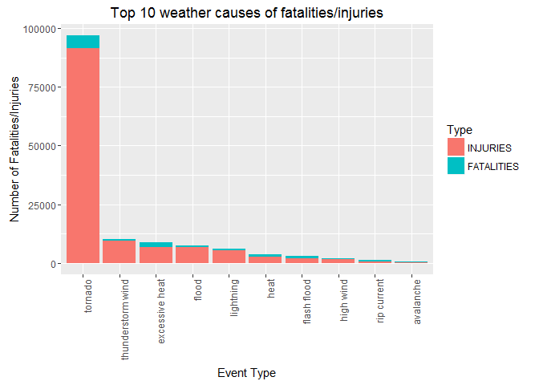

```
     Tornado is clearly the most dangerous weather event.
```

```r
health_data <- filtered_data[1:10,c("EVTYPE","INJURIES","FATALITIES")] %>%
    gather("fatality_type","value",2:3)

ggplot(health_data,aes(x=reorder(EVTYPE,-value),y=value,fill=fatality_type))+
    geom_bar(stat="identity")+
    theme(axis.text.x = element_text(angle = 90, hjust = 1))+
    xlab("Event Type")+
    ylab("Number of Fatalities/Injuries")+
    ggtitle("Top 10 weather causes of fatalities/injuries")+
    scale_fill_discrete(name="Type")
```

### Effects of weather events on economy

[figure not shown]

```
     Flooding has the biggest impact on the economy, closely followed by drought then hurricanes.
```

```r
economic_data <- arrange(filtered_data,desc(TOTAL_DMG))[1:10,c("EVTYPE","PROP_DMG","CROP_DMG")] %>%
    gather("economic_type","value",2:3) %>%
    mutate(value=value/1000000000)

ggplot(economic_data,aes(x=reorder(EVTYPE,-value),y=value,fill=economic_type))+
    geom_bar(stat="identity")+
    theme(axis.text.x = element_text(angle = 90, hjust = 1))+
    xlab("Event Type")+
    ylab("Damage in USD (billions)")+
    ggtitle("Top 10 weather causes of fatalities/injuries")+
    scale_fill_discrete(name="Type",
                        labels = c("PROPERTY","CROP"))
```